# Trip duration based on gender and age stage of riders of Ford GoBike's bicycles

## by (Wajeeh Alaidaroos)

## Investigation Overview

> In this investigation, I wanted to look at the age stage and the gender of Ford GoBike riders to the trip duration. The main focus was on Trip Duration, Member Gender, Member Age, and User Type.

## Dataset Overview

> The dataset here is about Ford GoBike Trip data. Ford GoBike is the Bay Area’s newest transportation option. The system will serve San Francisco, San Jose, Oakland, Berkeley and Emeryville. And Ford GoBike rapidly grow to 7,000 bikes at 546 stations by the end of 2018.

## Distribution of Genders

> About three-quarters of Ford GoBike's riders are males by 74.6%, then females are 23%, and other genders are 2.1%.

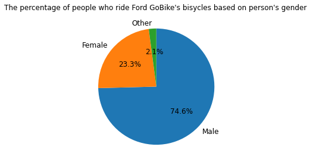

## Distribution of Trip Durations

> The most frequent trip durations is between 4-6 minutes, and after 6 minutes of the trip duration, the frequency decreases as we increasing the trip duration.

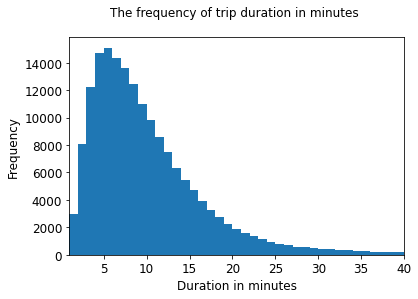

## Distribution of Ages

> From the age of 20 up to 75, most of the people who ride Ford GoBike's bicycles are between the age of 26 and 35, and the frequency decreases after the age of 33.

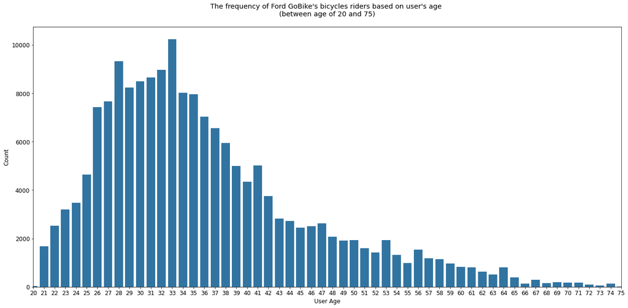

## Trip Duration and Rider Gender

> Females are spending more trip duration than Males by a few different, the median of Females trip duration is 10 minutes and colse to 30 minutes as a maximum, and for Males the median is about 9 minutes, and the maximum reaches 24 minutes, without taking outliers in consideration. (Excluding other genders)

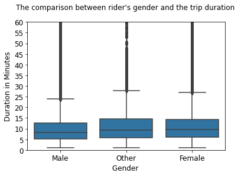

## Trip Durations by Rider Gender and Age Stage

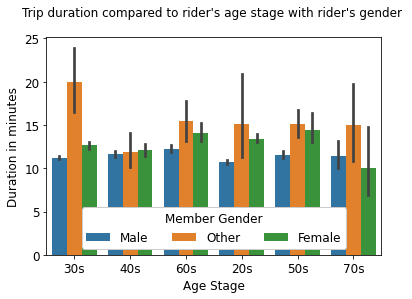